# STAT 5410 Final Project

Analysis of Area Codes

# DUE DATE: May 2nd, 2025.

# BACKGROUND

In 1947, the American Telephone and Telegraph company (AT&T) established the original North American area codes.

Telephone area codes are the three digits you dial preceding a phone number to designate a region in North America. For instance, the current area codes assigned to Connecticut are 203, 475, 860, and 959.

## The original area codes

Back in 1947, regions were assigned a single area code. In total, there were 86 initial regions spanning Canada and the US. Most US states, as well as DC, were assigned a single area code covering the entire state. For instance, Connecticut was assigned 203. Other more populous states were split up into multiple geographic regions, with each region getting its own code. For instance, Texas was split into four regions, assigned area codes 915, 214, 512, and 713.

Looking at Texas’s codes, they don’t really appear to follow any pattern except having a 1 in the middle. The same is true across the entire US. So, how were the actual numbers chosen for each region?

It turns out that experts and historians agree on some aspects of how the numbers were assigned, but other aspects remain disputed.

First, let’s cover the undisputed facts.

Any single area code state was assigned a code of the form `_0_`. That is, two numbers surrounding a zero digit. For instance, Connecticut originally had the single area code 203. Likewise, DC was assigned 202, and Virginia was assigned 703.

Meanwhile, multiple area code states were all assigned codes of the form `_1_`, like we saw for Texas. Massachusetts was assigned 617 for the area surrounding Boston, and 413 for the remainder.

Beyond this pattern for the middle digit, experts can’t agree on how the other digits were handed out. Some insist the choices were arbitrary, while others suggest alternative theories.

In particular, one leading theory involves the number “dial pulls” required for each number.

## The dial pull theory

Back in 1947, telephones were rotary. Dialing a telephone required entering digits one-by-one by spinning a wheel. The wheel started at the digit 1, then 2, then 3, progressing up to 9, and then finishing at 0. Consequently, dialing numbers involving early digits like 1 or 2 was easier and faster than dialing later digits like 8, 9, or 0.

Dialing the number 412 involves a total of 7 dial pulls, whereas dialing 902 requires 21 pulls (note that 0 requires 10).

If you are unfamiliar with rotary phones, this [Archival AT&T Instructional video on how to dial a rotary phone](https://youtube.com/watch?v=uaQm30DDHL8) might be helpful to appreciate the concept of “number of dial pulls”.

Coming back to the dial pull theory, experts note that the New York City region was assigned area code 212, the region containing Los Angeles was assigned the code 213, and the Chicago region was assigned 312. These three codes require 5, 6, and 6, dial pulls respectively. These were the shortest possible dials, because the leading digits of 1 were completely avoided and the code 211 was not assigned.

Recognizing that New York, Los Angeles, and Chicago are the USA’s three most populous cities, many view their low dials pulls as evidence that AT&T prioritized assigned fewer dial pulls to high population areas. Overall, this would lead to America having more efficient phone dials.

One the primary components of this project will be exploring and testing this “dial pull theory” versus the alternative that numbers were assigned arbitrarily.

Assembling the appropriate data and combining it into a useable format for this problem poses several challenges. For one, nicely formatted phone number data isn’t currently publicly available for 1947. Instead, we’ll need to work backward from current-day data.

I have already compiled and partially cleaned up/organized some datasets that will be useful to you, but the work is not complete. You’ll need to use STAT 5410 skills (data importing, tidying, and manipulating) to get the data set up to run your investigation.

In working backward from modern day data, you’ll be using information on how additional area codes were added to regions over time. They were added through a series of splits and overlays.

## Splits and overlays

Recall that Connecticut initially had just one area code. But now, it has four. These additional area codes were added over time to accommodate the need for more distinct telephone numbers. This same process has continued throughout the country, ever since 1947, as the demand for telephone numbers has increased.

New area codes are assigned to regions in one of two ways:

- A split: A geographic region that used to have just one area code is split in two and assigned two separate area codes. As such, those households broken off into the new region now have a new area code.
- An overlay: An additional area code is assigned to one (or more) geographic region(s) that already have area codes. Now, new phone numbers assigned in this area may have the new area code. No old numbers are impacted.

In modern days, new numbers are almost always added via overlay, as changing people’s existing phone numbers is a pain.

That said, for the purposes of this project, we don’t really need to differentiate between the splits and overlays. The important thing to know is that regions were initially were assigned a single area code back in 1947, but now most have multiple area codes. For instance, the entire state Florida initially was assigned just one area code. Now, it has over twenty!

In addition to helping us work backward to assemble the appropriate data to explore the “dial pull” theory, the number of splits and overlays per original area code will also play an important role in addressing another question related to the final component of the project.

Specifically, given information about a region corresponding to a single area code back in the 1947, how well can we predict how many modern day area codes it will have?

Your task will involve positing multiple models for this task, determining which fits the data best, and then drawing conclusions based on this determination.

In service of these tasks, I have compiled multiple datasets which I shall describe in the next section. Within these data lie all the information required to complete the project. That said, if you feel like incorporating additional data into your models, feel free to do so!

## Historical Note

For the purposes of this project, we will only consider regions that were US states at the time of number assignment in 1947, as well as the District of Columbia (DC). Other regions, including Alaska, Hawaii, Canada, Caribbean Islands, Central American countries, Puerto Rico, and any other US territories should be excluded from analysis as they do not fit this criteria.

# DATA PROVIDED

The following describe datasets I have provided to support your project. They are presented relatively cleanly, but I nonetheless recommend doing a cursory exploration of each of the datasets/variables to help understand the data, remove any unneeded rows, ensure the correct variable type, and perhaps assign more useful/matching variable names.

## AREA CODE DATA BY SELECT CITIES

The file `cities_area_codes.csv` contains roughly 32000 city-area code pairs from the modern day.

Its variables `city` and `state_or_province`, and `country` provide the name of a city/town and the state/province in which it is located.

`latitude` and `longitude` provide spatial coordinates within that city/town.

`area_code` provides a modern-day three digit area code assigned to this city.

Some notes:

- because cities now have multiple associated area codes, a city may occur multiple times in the dataset.
- the list is non-exhaustive. That is, not all possible area code/city combinations are included. So, don’t be worried if you do not see your particular city/area code combination.
- Moreover, not all cities/towns in the US are included. This data is just a hodge podge of cities that I was able to dig up, but it will be enough to adequately complete your task.

## COUNTY CENSUS INFO

The file `county_census_info.csv` contains helpful info assembled from the 1950 census, as well as some additional helpful information.

It contains 3123 rows, one for each county in the USA at the time.

The variable `state_name` provides the name of the state in upper case.

The variable `state_fips_code` provides the unique two-digit [Federal Information Processing System](https://transition.fcc.gov/oet/info/maps/census/fips/fips.txt) code assigned to the state.

Likewise, the variable `county_name` provides the name of the county, and the variable `county_fips_code` provides the unique three-digit county suffix for each individual county within its state.

These FIPS codes are helpful because they are easier to match than county names which are harder to standardize, and may change over time.

The variable `population_1950` provides the total population in the county as estimated by the 1950 census. Likewise, the variables `population_under5_1950`, `population_over65_1950`, and `black_pop` give the count of people aged below 5, above 65, and identified as Black/African American in the census.

The variable `residence_telephones_1945` provides the number of telephones in the county as 1945 (I was unable to find corresponding 1950 data).

The variable `births` provides the number of births in the county in 1950.

## SIMPLE FEATURES SHAPE FILE FOR US COUNTIES

The folder `co99_d00_shp` contains the shape file `co99_d00.shp` for the simple features map of the counties of the US.

In it, possibly relevant variables include:

- `AREA`: the area of the region in terms of thousands of square kilometers.
- `STATE`: providing the state FIPS code.
- `COUNTY`: providing the county FIPS code.
- `NAME`: Providing the name of the county
- `geometry` containing the simple features object of the area.

Note that this file contains states (like Alaska) and territories that will need to be excluded from the analysis. Also, many counties are split across multiple rows, as they region is comparised of non-contiguous shapes (e.g. islands).

## SPLITS AND OVERLAYS DATA

Recall that many of the original area codes now have new “descendant” area codes that were added to the region by process of either split or overlay.

The spreadsheet `splits_overlays.xlsx` contains one sheet for each of the original american area codes, labeled by the three digit area code. Within each sheet, there is a row for each of the current area codes now occupying that original region.

The column `code` provides the code, the column `year` provides the year that code was first used, the column `original` is a logical variable specifying whether or not it was the original area code for this region, and the `territory` variable gives a description of the area covered by the code today.

Depending on how you merge your data, one relevant bit of trivia is that the original area code 916 in California has completed moved area since it was originally proposed, meaning that it is not its own descendant (instead, it is a descendant of area code 415).

Note: I do not intend for you to have to use the `year` or `territory` variables in your analysis.

## NEW COUNTIES AND MERGED COUNTIES

Depending on how your approach your data merging, these files might be helpful for reconciling issues:

Since 1947, some counties have ceased to exist, and others have been created.

For those 16 counties that have ceased to exist, they have each been merged into another county. The file `merged_counties_since_1950.csv` contains a row for each county that got eliminated.

The variables `county_name`, `state_fips` and `state_name` provides the name, state fips code, and state of the county that was eliminated. The variable `old_county_fips` provides its fips code before it was eliminated. The variable `new_county_fips` provides the fips code of the county it was merged into.

For the two new counties that have been created, they were both created by breaking off a piece of existing counties.

The file `new_counties_since_1950.csv` contains a row for each. The variables `state`, `state_fips`, `old_county_name` and `old_county_fips` provide the name and FIPS of both the state and county where the separation happened, and the variables `new_county_name` and `new_county_fips` provide the name and FIPS for the new county that was created.

# PROJECT COMPONENTS

Using the data described above, the project requires you to complete the following tasks. For your reference, I have assigned a point total for each component.

## COMPONENT 1 [20 Points]

Create map visualizations of the complete areas corresponding to the original area codes.

Visualizing the entire USA leads to a graphic that is much too crowded with far too many area codes. As such, I request that you instead include individual graphics for six different states of your choice. The graphic should show a map of the state, with regions colored according to their area.

At least four of the states included must be from the list of multi-code states:

- California
- New York
- Texas
- Pennsylvania
- Ohio
- Illinois
- Minnesota
- Michigan
- Missouri
- Kansas
- Indiana
- Iowa
- Massachusetts
- Wisconsin

For your reference, [this website](https://lincmad.com/map1947.html) shows someone’s hand-drawn version of the approximate numbering plan for the entire US, using text instead of colors. [This technical report](https://underunderstood.com/podcast/wp-content/uploads/2021/03/NPA-History-and-Map.pdf) from Bell Labs contains a similar hand-drawn map (Map 3) on the final page. Because these maps are approximate—there is some uncertainty regarding boundaries of the original area codes—do not worry if your maps do not exactly match. For example, I have found that their map of California noticeably differs from mine.

**Note:** Even though I only want you to create graphics for six different states, you should nonetheless arrange the data for all of them, as this will be used in later components.

## COMPONENT 2 [15 Points]

Once you have created this data frame, verify that of the original area codes with middle digit 1, the three with the highest populations are `212`, `213`, and `312` corresponding to the areas containing New York City, Los Angeles, and Chicago, respectively.

Furthermore, create three additional graphics of your choosing exploring whichever aspects of this data interest you. Ensure that these figures are crisp and clear, with well-labeled axes. For each figure, provide a brief description of the interesting aspect of the data that is being highlighted. Feel free to be creative—the properties being explored do not necessarily have to correspond with the questions in the later components.

## COMPONENT 3 [15 Points]

Conduct an analysis to investigate the question: were higher population areas more likely to be assigned area codes that were faster to dial (required fewer dial pulls) on rotary phones? Or was the assignment of codes to regions essentially random?

Your analysis should include at least one formal hypothesis test with a p-value, as well as at least one graphic illustrating your findings.

Depending on how you approach the problem, it might be worth considering one-code and multiple-code states separately.

After conducting your hypothesis test, identify a few regions whose codes seem to be unfairly slow to dial given their population. Likewise, identify a few regions with codes that seem unfairly fast to dial.

Provide at least one graphic supporting these claims as well.

## COMPONENT 4 [10 Points]

The year 1947 predated some of the important anti-discrimination laws in the US, including Brown v. Board of Education, the Civil Rights act of 1964, and the voting rights act of 1965.

With regards to area code assignment, can you identify evidence of anti-black discrimination (in terms of dialing speed) by AT&T against regions with a larger proportion of black residents?

You may answer this question graphically, with a formal model/hypothesis test, or both.

## COMPONENT 5 [25 Points]

This component will focus on the task of predicting the current number of descendant area codes assigned to each original area code region, given data concerning that regions which was available in 1950 (e.g. number of births, total region area, number dial pulls, and the other data summarized in component 2).

Your write-up should include

- Proposing five different candidate models for the current number of area codes. The models may differ on aspects such as the variables included, algorithm used to fit, link function, etc.
- Devising a criteria on which to judge model performance.
- Determining which model performs best based on these criteria. This usually should involve some sort of cross-validation.
- Interpret the results of this model selection task. What sort of insights does the winning model tell us about the data? Include at least two graphics to support your claims.

## COMPONENT 6 [15 Points]

Organize and present your results as a polished report in a Quarto HTML file. The document should be clearly communicated: section headings, brief descriptions of your analyses, and comments on the figures and results. Do not feel like you need to write at length, but it is worth practicing writing up your conclusions clearly and concisely, along with accompanying figures, without relying on presenting raw code.

To maximize readability and presentation, use chunk modifiers such as `#| echo:FALSE`, `#| message: FALSE`, and `#| warning: FALSE` to avoid showing parts of your R code that are not related to the direct results.

In addition to your polished report, I’d like the opportunity to review your code, so please submit the `.qmd` file alongside your report. If you choose to conduct some of your pre-analysis and assembling of the data in a separate `.R` or `.qmd` file, please include that in your submission as well.

These 15 points associated with this section will be awarded based on the quality of how the results are presented in the report.

**Important Note:** When rendering your report as an HTML, ensure to use the setting `embed-resources: true` in the template as we do on Homework templates. Otherwise, your report may not display properly on my computer.

# ADDITIONAL RESOURCES

If you’re interested, the following resources may contain additional context related to this problem:

- The website lincmad.com contains a lot of information regarding area codes.
- In particular, this [page](https://lincmad.com/evolution.html) of lincmad contains a table similar to the `splits_overlays.xlsx` data I shared with you. Our data differs somewhat from this table, as this table allows for some counties to be split across multiple original area codes. To simplify things, I removed such ambiguities from our dataset.
- The podcast Underunderstood had an episode called [A Conspiracy Theory About Area Codes](https://underunderstood.com/podcast/episode/area-code-conspiracy-theory/) that explored the “dial pull” theory of area codes. It might be a fun listen!

# Additional Guidance

One the biggest challenges of this project will be assembling the data into a format thats allow you to complete the tasks at hand. In particular, formatting the data for components 1 and 2 will be challenging.

If you get stuck or don’t know where to start, the following are some of my hints/suggestions for how to attack components 1 and 2

### Component 1

Accomplishing this task will require you to figure out the original area code of each of the counties in the USA. It may be helpful to break this problem into different steps.

In your data, you have access to:

- the current area codes for a variety of cities in `cities_area_codes.csv`
- the current area codes corresponding to each of the original area codes in `splits_overlays.xlsx`

Using these, you should be able to determine the original area code assigned to each city.

Similarly, you have access to the

- the geographic region of each county in the `co99_d00.shp` file.
- the latitude and longitude of each of the cities in `cities_area_codes.csv`

Using these, you should be able to associate the cities with their counties. Combining this information together, you should then be able to assign an original area code to each of the counties for which you have a city in `cities_area_codes.csv`. I have made sure to include at least one city from every county. So, if you combine the information correctly, you will obtain a single original area code for every county in the US.

With these, you should be able to make plots for every state, similar to the following one I created for Iowa.

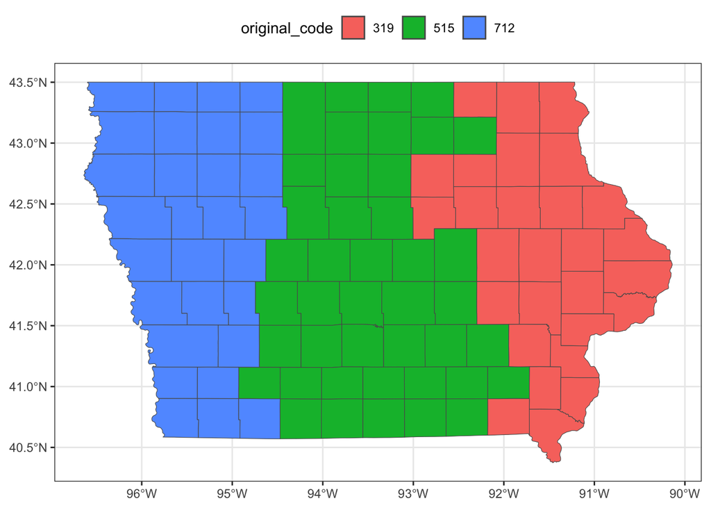

### Component 2

To complete component 2, you’ll need to know the 1950 population associated with each original area code, as well as the other relevant variables.

The `county_census_info.csv` provides the 1950 population and related variables for each county that existed in 1950. The results of Component 1 provide the original area code associated with each modern county. Thus, you should be able to combine and summarize these two datasets to get the desired quantities.

One caveat is that there is a small misalignment between the counties present in 1950 versus the counties present today. Depending on how you approach the problem, this misalignment has the potential to cause problems. If it does, the data described above in Section 3.5 may be helpful.

Computing the number of dial pulls can be accomplished using a custom function.

Once you’ve completed the data frame, I suggest checking your work by verifying that the sum of your 1950 populations matches the sum of the relevant data in the original county data frame—which is roughly 150 million people. Similarly, the sum of the areas should be just under 820 000 square kilometers.

Please, feel free to reach out or post on HuskyCT if you run into any issues or have concerns.